# IMDB Review Sentiment Analysis

## Introduction

Sentiment analysis, also referred to as opinion mining, is an approach to natural language processing (NLP) that identifies the emotional tone behind a body of text. This is a popular way for organizations to determine and categorize opinions about a product, service or idea.

The objective of this study is to understand and implement a method of subfield study of NLP which is to transform the words into vectors, and to apply different machine learning models including Logistic Regression, Decision Tree Classifier, Random Forest, K-nearest neighbors, Support Vector Machine, Naive Bayes to a dataset of moview reviews to classify the movie reviews into positive or negative category.

## Description of dataset

The Internet Movie Database(IMDb) that has been collected by Andrew Mass and other (**Andrew L. Maas, Raymond E. Daly, Peter T. Pham, Dan Huang, Andrew Y. Ng, and Christopher Potts. (2011). Learning Word Vectors for Sentiment Analysis. The 49th Annual Meeting of the Association for Computational Linguistics (ACL 2011)**).

The movie review dataset consists of 50,000 popular movie reviews that are labeled as either positive or negative. A positive means that a movie received more than six stars on IMDb, and a negative means that a movie was rated with less than five stars on IMDb.

We will have to extract meaningful information from a subset of of these movie reviews to develop a machine learning model that predicts whether a certain reviewer liked of disliked a movie.

## Obtaining the dataset

You can either download the dataset in a csv file from Kaggle at following link https://www.kaggle.com/datasets/hamditarek/imdb-dataset-50k-maas-et-al-2011  
The csv file is about 80 mb, quite large.  
Or a compressed archive of the dataset can be downloaded from https://ai.stanford.edu/~amaas/data/sentiment/  
I downloaded the archive file directly from Andrew Mass personal website at Standford University and use Python to extract the tar file.

```python
import tarfile
with tarfile.open('aclImdb_v1.tar.gz', 'r:gz') as tar:
    tar.extractall()
```

## Preprocessing the dataset

Having fully extracted the dataset, I will have to assemble the individual text documents from the decompressed folder into a single CSV file. The dataset was split into 25,000 samples for train in the train folder and 25,000 samples for test in the test folder. And in each folder, the data was split into subsequent folders named pos for positive reviews, and neg for negative reviews. So basically we have two features here: Review and Sentiment. I will create a dataframe and store the individual text as review and its sentiment appropriately for all the data. This could take up to 5-10 minutes depending on the processor of the computer you are working on.

```python
import pandas as pd
import os

basepath = 'aclImdb'
lables = {'pos':1, 'neg':0}
df = pd.DataFrame()

for i in ('test', 'train'):
    for j in ('pos','neg'):
        path = os.path.join(basepath,i,j)
        for file in sorted(os.listdir(path)):
            with open(os.path.join(path,file),'r', encoding = 'utf-8') as infile:
                txt = infile.read()
                df = df.append([[txt,lables[j]]], ignore_index= True)
df.columns =['review','sentiment']
```

## Checking the dataset and save to CSV file for future use

Now after I have successfully assembled the data into a dataframe. Let's confirm we have the right dataset and save it into a CSV file named 'movie_data.csv' After saving it into a CSV file, I will read the data from the CSV file to check whether or not I have successfully saved the data in the right format.

```python
import numpy as np


np.random.seed(0)

df = df.reindex(np.random.permutation(df.index)) #shuffle the index
df.to_csv('movie_data.csv', index= False,encoding ='utf-8')
```

```python
import pandas as pd
df = pd.DataFrame()
df = pd.read_csv('movie_data.csv', encoding ='utf-8')
df.head()
```

|  | review | sentiment |
| --- | --- | --- |
| 0 | In 1974, the teenager Martha Moxley (Maggie Gr... | 1 |
| 1 | OK... so... I really like Kris Kristofferson a... | 0 |
| 2 | ***SPOILER*** Do not read this, if you think a... | 0 |
| 3 | hi for all the people who have seen this wonde... | 1 |
| 4 | I recently bought the DVD, forgetting just how... | 0 |

## Data Cleaning and Exploratory Data Analysis (EDA)

After successfully checking that I have got the right data format. Let's do some data checking and cleaning as well as some exploratory analysis.

```python
df.describe()
```

|  | sentiment |
| --- | --- |
| count | 50000.000000 |
| mean | 0.500000 |
| std | 0.500005 |
| min | 0.000000 |
| 25% | 0.000000 |
| 50% | 0.500000 |
| 75% | 1.000000 |
| max | 1.000000 |

```
[Text(0.5, 1.0, 'Positive Comments vs Negative Comments')]
```

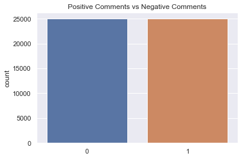

```python
import seaborn as sns
sns.set(style='darkgrid')
sns.countplot(df['sentiment'].values).set(title='Positive Comments vs Negative Comments')
```

*I can see the dataset is balanced.*

```python
df.info()
```

```
<class 'pandas.core.frame.DataFrame'>
RangeIndex: 50000 entries, 0 to 49999
Data columns (total 2 columns):
 #   Column     Non-Null Count  Dtype
---  ------     --------------  -----
 0   review     50000 non-null  object
 1   sentiment  50000 non-null  int64
dtypes: int64(1), object(1)
memory usage: 781.4+ KB
```

```python
df.isna().sum()
```

```
review       0
sentiment    0
dtype: int64
```

```python
df.isnull().sum()
```

```
review       0
sentiment    0
dtype: int64
```

*I can see no missing values here*

```python
df.duplicated().sum()
```

```
418
```

*I can see 418 duplicated values so I will remove them by keeping the first and remove the rest.*

```python
df = df.drop_duplicates(keep='first', ignore_index = True)
```

```python
df.shape
```

```
(49582, 2)
```

```python
df['review']
```

```
0        In 1974, the teenager Martha Moxley (Maggie Gr...
1        OK... so... I really like Kris Kristofferson a...
2        ***SPOILER*** Do not read this, if you think a...
3        hi for all the people who have seen this wonde...
4        I recently bought the DVD, forgetting just how...
                               ...
49577    OK, lets start with the best. the building. al...
49578    The British 'heritage film' industry is out of...
49579    I don't even know where to begin on this one. ...
49580    Richard Tyler is a little boy who is scared of...
49581    I waited long to watch this movie. Also becaus...
Name: review, Length: 49582, dtype: object
```

**Let's check out the first review to see what kind of characters in the review. I may need to clean up the non-character words**

```python
df.loc[0,'review']
```

```
'In 1974, the teenager Martha Moxley (Maggie Grace) moves to the high-class area of Belle Haven, Greenwich, Connecticut. On the Mischief Night, eve of Halloween, she was murdered in the backyard of her house and her murder remained unsolved. Twenty-two years later, the writer Mark Fuhrman (Christoph…
```

**I can see that the text contains HTML markup as well as punctuation, other non-letters. I will remove them except for emoticons character such as :). I use the Python's regular expression lbirary for the task.**

```python
import re
def preprocessor(text):
    text = re.sub('<[^>]*>','',text)
    emoticons = re.findall('(?::|;|-)(?:-)?(?:\)|\(D|P)',text)
    text = (re.sub('[\W]+',' ',text.lower()) + ' '.join(emoticons).replace('-',''))
    return text
```

The first regex <[^>]*> is to remove all the HTML markups. The second regex (?::|;|-)(?:-)?(?:)|(D|P) is to find all the emoticons in the text. And the last regex [\W]+ is to remove all the non-words character. Finally I convert text into lowercase and combine with the emoticon attached at the end of the text. Let's see if the function preprocessor is working well.

```python
preprocessor(df.loc[0,'review'])
```

```
'in 1974 the teenager martha moxley maggie grace moves to the high class area of belle haven greenwich connecticut on the mischief night eve of halloween she was murdered in the backyard of her house and her murder remained unsolved twenty two years later the writer mark fuhrman christopher meloni w…
```

**The preprocessor function seems to work well. So let's apply the fuction to the data review column.**

```python
df['review'] = df['review'].apply(preprocessor)
df['review']
```

```
0        in 1974 the teenager martha moxley maggie grac...
1        ok so i really like kris kristofferson and his...
2         spoiler do not read this if you think about w...
3        hi for all the people who have seen this wonde...
4        i recently bought the dvd forgetting just how ...
                               ...
49577    ok lets start with the best the building altho...
49578    the british heritage film industry is out of c...
49579    i don t even know where to begin on this one i...
49580    richard tyler is a little boy who is scared of...
49581    i waited long to watch this movie also because...
Name: review, Length: 49582, dtype: object
```

**The data review column now only contains characters words. Moreover, I want to process each review into tokens so I'll create a tokenizer function as follow**

```python
def tokenizer(text):
    return text.split()
```

```python
import nltk
nltk.download('stopwords')
from nltk.corpus import stopwords
def stop_words(text):
    stop = stopwords.words('english')
    return [w for w in tokenizer(text) if w not in stop]
```

**After defining the function stop_words, let's apply stop_words to filter all stop words from our review column.**

```python
df['review'] = df['review'].apply(stop_words)
df['review']
```

```
0        [1974, teenager, martha, moxley, maggie, grace...
1        [ok, really, like, kris, kristofferson, usual,...
2        [spoiler, read, think, watching, movie, althou...
3        [hi, people, seen, wonderful, movie, im, sure,...
4        [recently, bought, dvd, forgetting, much, hate...
                               ...
49577    [ok, lets, start, best, building, although, ha...
49578    [british, heritage, film, industry, control, n...
49579    [even, know, begin, one, family, worst, line, ...
49580    [richard, tyler, little, boy, scared, everythi...
49581    [waited, long, watch, movie, also, like, bruce...
Name: review, Length: 49582, dtype: object
```

**Finding the most frequent words in the dataset including most frequent words for positive and negative comments**

```python
from collections import defaultdict

def vocab_count(docs):
    vocab = defaultdict(int)
    for doc in docs:
        for token in doc:
            if token not in vocab:
                    vocab[token] = 1
            else:
                    vocab[token] += 1
    return vocab
```

```
movie : 87237

film : 79116

one : 53187

like : 39831

good : 29531

time : 24895

even : 24652

would : 24398

story : 22960

really : 22918
```

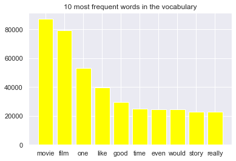

```python
from matplotlib import pyplot as plt

bag_of_words = vocab_count(df['review'].values)

bag_of_words = {word:count for word,count in sorted(bag_of_words.items(), reverse = True, key = lambda item:item[1])}
words = list(bag_of_words.keys())
counts = list(bag_of_words.values())

for i in range(0,10):
    print(words[i] +' : '+ str(counts[i]) + '\n')

plt.title('10 most frequent words in the vocabulary')
plt.bar(words[0:10],counts[0:10], color ='yellow')
plt.show()
```

**Now let's print out the 10 most frequent words with its frequencies for positive comments, then plot the bar graph**

```
film : 41953

movie : 37649

one : 27202

like : 17646

good : 14961

story : 12895

great : 12886

time : 12695

well : 12678

see : 12220
```

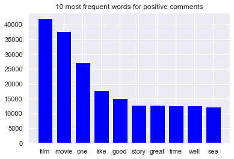

```python
positive_reviews = df.loc[df['sentiment']==1]

positive_words = vocab_count(positive_reviews['review'].values)
positive_words = {word:count for word,count in sorted(positive_words.items(), reverse = True, key = lambda item:item[1])}

words = list(positive_words.keys())
counts = list(positive_words.values())

for i in range(0,10):
    print(words[i]+' : '+ str(counts[i]) + '\n')
plt.title('10 most frequent words for positive comments')
plt.bar(words[0:10],counts[0:10], color ='blue')
plt.show()
```

**Now let's print out the 10 most frequent words with its frequencies for negative comments, then plot the bar graph**

```
movie : 49588

film : 37163

one : 25985

like : 22185

even : 15084

good : 14570

bad : 14551

would : 13852

really : 12216

time : 12200
```

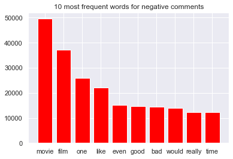

```python
negative_reviews = df.loc[df['sentiment']==0]

negative_words = vocab_count(negative_reviews['review'].values)

negative_words = {word:count for word,count in sorted(negative_words.items(), reverse = True, key = lambda item:item[1])}
words = list(negative_words.keys())
counts = list(negative_words.values())

for i in range(0,10):
    print(words[i]+' : '+ str(counts[i]) + '\n')

plt.title('10 most frequent words for negative comments')
plt.bar(words[0:10],counts[0:10], color ='red')
plt.show()
```

**As observed, the words 'movie' or 'film' actually happens to have the highest frequency for both positive and negative comments. Because this is the IMDb reviews so of course not so supprisingly that 'movie' and 'film' are the most frequent words.**

**Transforming words into feature vector:The bag-of-words model, which allows us to represent text as numerical features.**

1. Create a vocabulary of unique tokens such as words from the entire set of documents.
2. Construct a vector from each document that contains the counts of how often each word occurs in the particular document.

Because we have such quite large dataset. It will take a lot of computer memory to vectorize all the words. However the scipy kit provides a sparse matrix class called csr_matrix which is a compressed matrix, very efficient for computing and caluclating matrix.Let's use that and see how MyCountVectorizer works.

```python
import numpy as np
from scipy.sparse import csr_matrix

class MyCountVectorizer:

    def __init__(self):
        self.vocab = {}
    def fit_transform(self, docs):

        #build vocabulary

        for doc in docs:
            for token in doc:
                if token not in self.vocab:
                    self.vocab[token] = len(self.vocab) #set the token value = length of vocab at setting

        #build document-term matrix
        #each row represents a document and each column represents a token in the vocabulary
        #the value at the intersection of row i and column j represents the count of the jth token in the ith document

        row = []
        col = []
        data = []
        for i, doc in enumerate(docs):
            for token in doc:
                row.append(i)
                col.append(self.vocab[token])
                data.append(doc.count(token))
        return csr_matrix((data, (row, col)), shape=(len(docs), len(self.vocab)))
```

```python
count = MyCountVectorizer()
count.fit_transform(df['review'].values).toarray()
```

```
array([[1, 4, 4, ..., 0, 0, 0],
       [0, 0, 0, ..., 0, 0, 0],
       [0, 0, 0, ..., 0, 0, 0],
       ...,
       [0, 0, 0, ..., 0, 0, 0],
       [0, 0, 0, ..., 0, 0, 0],
       [0, 0, 0, ..., 0, 0, 0]], dtype=int32)
```

**A method to downweight the frequently occuring words in the feature vectors called term frequency-inverse document frequency (tf-idf). The tf-idf can be defined as the product of the term frequency and the inverse document frequency:** *tf-idf(t,d)=tf(t,d)xidf(t,d).*  
**Here *tf(t,d)* is the term frequency and idf(t,d) is the inverse document frequency which is computed as follows:** *idf(t,d) = log((n)/(1+df(t,d)) where df(t,d) is the number of documents that contains the term and n is the total number of documents.*  
**Please note that sklearn has all the libraries such as CountVectorizer or TfidfVectorizer that do all the works for us, however because of the objective of this study I will try to implement from the scratch to understand the way it works around.**

```python
import numpy as np

class MyTfidfTransformer:

    def __init__(self):
        self.doc_term_matrix = None
        self.idf = None

    def fit_transform(self, doc_term_matrix):
        #build document-term matrix
        self.doc_term_matrix = doc_term_matrix

        #calculate IDF for each term
        df = np.sum(doc_term_matrix != 0, axis=0)
        idf = np.log((doc_term_matrix.shape[0]) / (df + 1))
        self.idf = csr_matrix(idf)

        #calculate TF-IDF for each document-term pair
        self.doc_term_matrix = self.doc_term_matrix.multiply(self.idf)

        #Normalize the weight by L2-normalization
        self.doc_term_matrix = self.doc_term_matrix.multiply(1.0 / np.sqrt(self.doc_term_matrix.power(2).sum(axis=1)))

        return self.doc_term_matrix
```

**After implementing MyTfidfTransformer, I use its function to convert review column into vector. I will save the data as X for all review vector array, and y as prediction array**

```python
tfidf = MyTfidfTransformer()
X = tfidf.fit_transform(MyCountVectorizer().fit_transform(df['review'].values))
X
```

```
<49582x104038 sparse matrix of type '<class 'numpy.float64'>'
	with 4874514 stored elements in COOrdinate format>
```

```python
y= df['sentiment'].values
y
```

```
array([1, 0, 0, ..., 0, 0, 1], dtype=int64)
```

## Model Analysis

**After cleaning and transforming the dataset into feature vectors, I will split the dataset into train set and test set with 50% size for each. Then I'll will try to apply a few classifcation methods to build the best model to predict.**

```python
from sklearn.model_selection import train_test_split
X_train, X_test, y_train, y_test = train_test_split(X,y,test_size =0.5, random_state =42)
print(X_train.shape)
print(X_test.shape)
print(y_train.shape)
print(y_test.shape)

accuracy_score_list = []
precision_score_list = []
recall_score_list = []
auc_score_list = []
```

```
(24791, 104038)
(24791, 104038)
(24791,)
(24791,)
```

**I want to develop a few help functions to caculate precision as well as recall, to plot ROC curve and confusion matrix**

```python
def calculate_precision(y_true, y_pred, pos_label_value=1.0):

    from sklearn.metrics import precision_score

    return precision_score(y_true,y_pred, pos_label=pos_label_value)

def calculate_recall(y_true, y_pred, pos_label_value=1.0):


    from sklearn.metrics import recall_score

    return recall_score(y_true,y_pred, pos_label=pos_label_value)

def plot_roc(y_test,y_pred):

    from sklearn.metrics import roc_auc_score
    from sklearn.metrics import roc_curve
    import matplotlib.pyplot as plt


    fpr,tpr, th = roc_curve(y_test,y_pred[:,1])
    auc = roc_auc_score(y_test, y_pred[:,1])
    plt.plot(fpr,tpr)
    plt.plot(np.arange(0,1.1,0.1), np.arange(0,1.1,0.1), 'r--')
    plt.ylabel("True Positive Rate")
    plt.xlabel("False Positive Rate")
    plt.title("ROC Curve")
    plt.text(0.7,0.2,'AUC=' + "{:.3f}".format(auc))
    plt.show()

def plot_confusion_matrix(conf_matrix):

    import matplotlib.pyplot as plt

    plt.figure(figsize=(4,3), dpi=100)

    sns.set(font_scale = 1.1)

    ax = sns.heatmap(conf_matrix, annot=True, fmt='d', )

    ax.set_xlabel("Prediction", fontsize=14, labelpad=20)
    ax.xaxis.set_ticklabels(['Negative', 'Positive'])

    ax.set_ylabel("Actual", fontsize=14, labelpad=20)
    ax.yaxis.set_ticklabels(['Negative', 'Positive'])

    ax.set_title("Confusion Matrix", fontsize=14, pad=20)

    plt.show()
```

### Logistic Regression

```python
from sklearn.linear_model import LogisticRegression
LogReg = LogisticRegression(solver='liblinear').fit(X_train,y_train)
LogReg.coef_
```

```
array([[ 0.09986267, -0.38897876, -0.4112875 , ...,  0.        ,
         0.        ,  0.        ]])
```

```python
y_pred = LogReg.predict(X_test)

acc_score = LogReg.score(X_test,y_test)
precision = calculate_precision(y_test,y_pred)
recall = calculate_recall(y_test,y_pred)

print("Precision Score: ", precision)
print("Recall Score: ", recall)
print("Accuracy Score:", acc_score)
```

```
Precision Score:  0.8480720387901177
Recall Score:  0.8845628963634904
Accuracy Score: 0.862369408252995
```

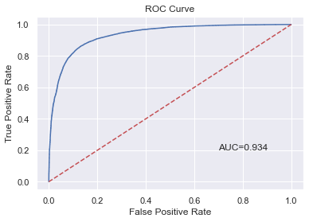

```python
y_pred = LogReg.predict_proba(X_test)
plot_roc(y_test,y_pred)
```

**K-Fold cross validation for logistic regession with 5-fold, 10-fold**

```python
from sklearn.model_selection import KFold
from sklearn.model_selection import cross_val_predict
from sklearn.model_selection import cross_val_score

model = LogisticRegression(solver ='liblinear',max_iter=1000)

y_pred = cross_val_predict(model,X_test,y_test, cv=5)

acc_score = cross_val_score(model,X_test,y_test, cv= 5)
precision = calculate_precision(y_test,y_pred)
recall = calculate_recall(y_test,y_pred)
print("Precision Score for 5-fold: ",precision)
print("Recall Score for 5-fold: ", recall)
print("Accuracy Score for 5-fold:", np.mean(acc_score))

y_pred = cross_val_predict(model,X_test,y_test, cv=10)

acc_score = cross_val_score(model,X_test,y_test, cv= 10)
precision = calculate_precision(y_test,y_pred)
recall = calculate_recall(y_test,y_pred)
print("Precision Score for 10-fold: ",precision)
print("Recall Score for 10-fold: ", recall)
print("Accuracy Score for 10-fold:", np.mean(acc_score))
```

[output not shown]

**It seems our model does not suffer from overfitting. Let's try to apply the GridSearch 10-fold for Logistic Regression with parameters penalty, C**

```python
from sklearn.model_selection import GridSearchCV
c_range = [1.0,10.0,100.0]
penalty = ['l1','l2']
parameters = {'C':c_range, 'penalty':penalty}
model = LogisticRegression(solver='liblinear', max_iter=1000)
grid = GridSearchCV(model,parameters, cv=10).fit(X_train,y_train)
print('Best Accuracy:', grid.best_score_)
print('Best Parameters:',grid.best_params_)
```

```
Best Accuracy: 0.8644664699605722
Best Parameters: {'C': 10.0, 'penalty': 'l2'}
```

```python
from sklearn.metrics import roc_auc_score

model = grid.best_estimator_
y_pred = model.predict(X_test)

acc_score = model.score(X_test,y_test)

precision = calculate_precision(y_test,y_pred)
recall = calculate_recall(y_test,y_pred)

accuracy_score_list.append(acc_score)
precision_score_list.append(precision)
recall_score_list.append(recall)


print("Precision Score: ",precision)
print("Recall Score: ",recall)
print("Accuracy Score:", acc_score)
```

```
Precision Score:  0.8565599497802887
Recall Score:  0.8762944529180381
Accuracy Score: 0.8641039086765359
```

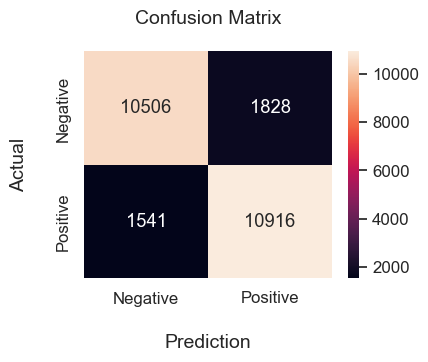

```python
from sklearn.metrics import confusion_matrix
conf_matrix = confusion_matrix(y_test,y_pred)
plot_confusion_matrix(conf_matrix)
```

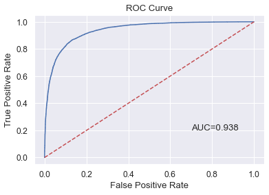

```python
y_pred = model.predict_proba(X_test)
auc_score = roc_auc_score(y_test, y_pred[:,1])
auc_score_list.append(auc_score)
plot_roc(y_test,y_pred)
```

### Decision Tree Classifier

```python
from sklearn.tree import DecisionTreeClassifier
def build_dt(data_X, data_y, max_depth = None, max_leaf_nodes =None):

    clf = DecisionTreeClassifier(max_depth = max_depth,max_leaf_nodes = max_leaf_nodes)
    return clf.fit(data_X, data_y)
```

**Let's try the decision tree classifier with max_depth =2**

```python
model = build_dt(X_train,y_train,max_depth=2)
y_pred = model.predict(X_test)

acc_score = model.score(X_test,y_test)
precision = calculate_precision(y_test,y_pred)
recall = calculate_recall(y_test,y_pred)
tree_depth = model.get_depth()

print("Precision Score: ",precision)
print("Recall Score: ", recall)
print("Depth of Tree: ", tree_depth)
print("Accuracy Score:", acc_score)
```

```
Precision Score:  0.6029138928298592
Recall Score:  0.8869711808621659
Depth of Tree:  2
Accuracy Score: 0.6496712516639103
```

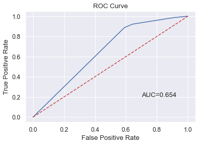

```python
y_pred = model.predict_proba(X_test)
plot_roc(y_test,y_pred)
```

**Let's try the decision tree classifier with max_leaf_nodes = 5**

```python
model = build_dt(X_train,y_train,max_leaf_nodes = 5)
y_pred = model.predict(X_test)

acc_score = model.score(X_test,y_test)
precision = calculate_precision(y_test,y_pred)
recall = calculate_recall(y_test,y_pred)
tree_depth = model.get_depth()

print("Precision Score: ",precision)
print("Recall Score: ", recall)
print("Depth of Tree: ", tree_depth)
print("Accuracy Score:", acc_score)
```

```
Precision Score:  0.6374560375146542
Recall Score:  0.8730031307698483
Depth of Tree:  4
Accuracy Score: 0.6867008188455488
```

**Let's try the decision tree classifier with max_depth = 10**

```python
model = build_dt(X_train,y_train,max_depth=10)
y_pred = model.predict(X_test)

acc_score = model.score(X_test,y_test)
precision = calculate_precision(y_test,y_pred)
recall = calculate_recall(y_test,y_pred)
tree_depth = model.get_depth()



accuracy_score_list.append(acc_score)
precision_score_list.append(precision)
recall_score_list.append(recall)

print("Precision Score: ",precision)
print("Recall Score: ", recall)
print("Depth of Tree: ", tree_depth)
print("Accuracy Score:", acc_score)
```

```
Precision Score:  0.6817149899461633
Recall Score:  0.8437023360359637
Depth of Tree:  10
Accuracy Score: 0.7235286999314268
```

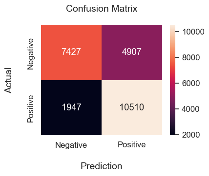

```python
conf_matrix = confusion_matrix(y_test,y_pred)
plot_confusion_matrix(conf_matrix)
```

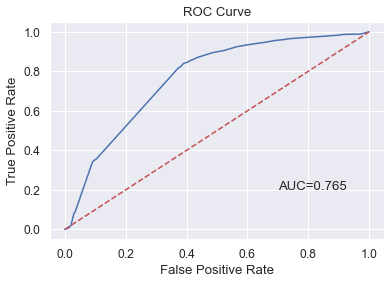

```python
y_pred = model.predict_proba(X_test)
auc_score = roc_auc_score(y_test, y_pred[:,1])
auc_score_list.append(auc_score)

plot_roc(y_test,y_pred)
```

### Random Forest

```python
from sklearn.ensemble import RandomForestClassifier

rf = RandomForestClassifier(n_estimators=200, max_depth= 10, min_samples_leaf = 7, criterion='gini').fit(X_train,y_train)
y_pred = rf.predict(X_test)

acc_score = rf.score(X_test,y_test)
pred_score = 1-acc_score
precision = calculate_precision(y_test,y_pred)
recall = calculate_recall(y_test,y_pred)


accuracy_score_list.append(acc_score)
precision_score_list.append(precision)
recall_score_list.append(recall)


print('Misclassification error on test data : %0.3f'%pred_score)
print("Precision Score: ",precision)
print("Recall Score: ", recall)
print("Accuracy Score:", acc_score)
```

```
Misclassification error on test data : 0.170
Precision Score:  0.7911924789708066
Recall Score:  0.898530946455808
Accuracy Score: 0.8298576096163931
```

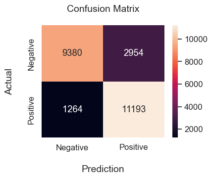

```python
conf_matrix = confusion_matrix(y_test,y_pred)
plot_confusion_matrix(conf_matrix)
```

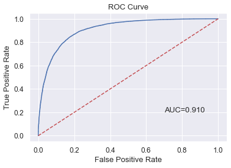

```python
y_pred = rf.predict_proba(X_test)
auc_score = roc_auc_score(y_test, y_pred[:,1])
auc_score_list.append(auc_score)
plot_roc(y_test,y_pred)
```

### K-nearest neighbors classfier

```python
from sklearn.neighbors import KNeighborsClassifier
model = KNeighborsClassifier(weights ='distance').fit(X_train,y_train)

y_pred = model.predict(X_test)

acc_score = model.score(X_test,y_test)
precision = calculate_precision(y_test,y_pred)
recall = calculate_recall(y_test,y_pred)

print("Precision Score: ",precision)
print("Recall Score: ", recall)
print("Accuracy Score:", acc_score)
```

```
Precision Score:  0.672014652014652
Recall Score:  0.7363731235449947
Accuracy Score: 0.6869428421604614
```

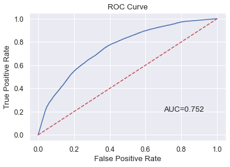

```python
y_pred = model.predict_proba(X_test)
plot_roc(y_test,y_pred)
```

**Let's try GridSearch with 10-fold cross validation for parameters n_neighbors**

```python
from sklearn.model_selection import GridSearchCV
k_range = list(range(1,31))
parameters = {'n_neighbors':k_range}
model = KNeighborsClassifier(weights ='distance')
grid = GridSearchCV(model,parameters, cv=10).fit(X_train,y_train)
print('Best Accuracy:', grid.best_score_)
print('Best Parameters:',grid.best_params_)
```

```
Best Accuracy: 0.7055778539733764
Best Parameters: {'n_neighbors': 26}
```

```python
model = grid.best_estimator_
y_pred = model.predict(X_test)

precision = calculate_precision(y_test,y_pred)
recall = calculate_recall(y_test,y_pred)
acc_score = model.score(X_test,y_test)

accuracy_score_list.append(acc_score)
precision_score_list.append(precision)
recall_score_list.append(recall)


print("Precision Score: ",precision)
print("Recall Score: ",recall)
print("Accuracy Score:", acc_score)
```

```
Precision Score:  0.6909691629955947
Recall Score:  0.7554788472344867
Accuracy Score: 0.70735347505143
```

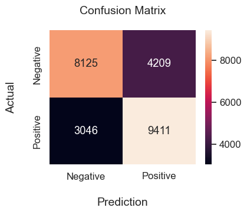

```python
conf_matrix = confusion_matrix(y_test,y_pred)
plot_confusion_matrix(conf_matrix)
```

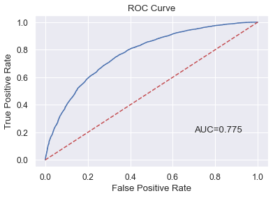

```python
y_pred = model.predict_proba(X_test)
auc_score = roc_auc_score(y_test, y_pred[:,1])
auc_score_list.append(auc_score)
plot_roc(y_test,y_pred)
```

### Support Vector Machine

**I will have to implement a predict probability function for LinearSVC since it does not have the predict_proba function. Also, I can use SVC with kerner ='linear' but it takes much longer time to compute than LinearSVC and gives the same result**

```python
import numpy as np

def LinearSVC_predict_proba(model, X):
    # Compute the distances between each sample and the decision hyperplane
    distances = model.decision_function(X)

    # Convert distances to probabilities using a calibrated sigmoid function
    proba = 1 / (1 + np.exp(-distances))
    proba = np.vstack([1 - proba, proba]).T

    return proba
```

```python
from sklearn.svm import LinearSVC
lsvm = LinearSVC(loss='hinge').fit(X_train,y_train)
y_pred = lsvm.predict(X_test)
acc_score = lsvm.score(X_test,y_test)
precision = calculate_precision(y_test,y_pred)
recall = calculate_recall(y_test,y_pred)
print("Precision Score: ",precision)
print("Recall Score: ", recall)
print("Accuracy Score:", acc_score)
```

```
Precision Score:  0.853704136480486
Recall Score:  0.8797463273661396
Accuracy Score: 0.863821548142471
```

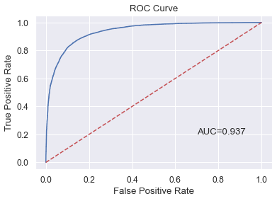

```python
y_pred = LinearSVC_predict_proba(lsvm,X_test)
plot_roc(y_test,y_pred)
```

**Implement a GridSearchCV for LinearSVC with parameters 'C' and 'loss'. Here 'C' takes value from 2^(-3) to 2^(3) and 'loss' can be squared_hinge or hinge**

```python
from sklearn.model_selection import GridSearchCV
c_range = [2**i for i in range(-3,4)]
loss = ['hinge','squared_hinge']
parameters = {'C':c_range, 'loss':loss}
svc = LinearSVC(max_iter=10000)
grid = GridSearchCV(svc,parameters, cv=10).fit(X_train,y_train)
print('Best Accuracy:', grid.best_score_)
print('Best Parameters:',grid.best_params_)
```

```
Best Accuracy: 0.8653541197673359
Best Parameters: {'C': 0.25, 'loss': 'squared_hinge'}
```

```python
lsvm = grid.best_estimator_
y_pred = lsvm.predict(X_test)

acc_score = lsvm.score(X_test,y_test)
precision = calculate_precision(y_test,y_pred)
recall = calculate_recall(y_test,y_pred)

accuracy_score_list.append(acc_score)
precision_score_list.append(precision)
recall_score_list.append(recall)

print("Precision Score: ",precision)
print("Recall Score: ", recall)
print("Accuracy Score:", acc_score)
```

```
Precision Score:  0.8545722485069418
Recall Score:  0.8844826202135345
Accuracy Score: 0.866322455729902
```

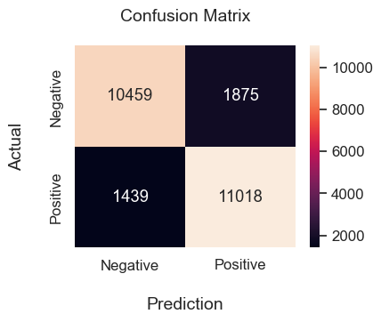

```python
conf_matrix = confusion_matrix(y_test,y_pred)
plot_confusion_matrix(conf_matrix)
```

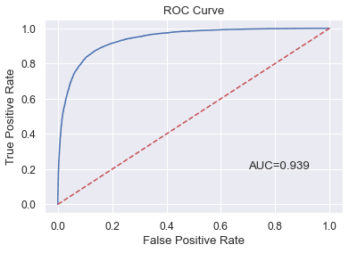

```python
y_pred = LinearSVC_predict_proba(lsvm,X_test)
auc_score = roc_auc_score(y_test, y_pred[:,1])
auc_score_list.append(auc_score)

plot_roc(y_test,y_pred)
```

### Naive Bayes Classification

```python
from sklearn.naive_bayes import BernoulliNB
nb = BernoulliNB().fit(X_train,y_train)
y_pred = nb.predict(X_test)
acc_score = nb.score(X_test,y_test)
precision = calculate_precision(y_test,y_pred)
recall = calculate_recall(y_test,y_pred)


accuracy_score_list.append(acc_score)
precision_score_list.append(precision)
recall_score_list.append(recall)

print("Precision Score: ",precision)
print("Recall Score: ", recall)
print("Accuracy Score:", acc_score)
```

```
Precision Score:  0.8754346314325452
Recall Score:  0.8084611062053464
Accuracy Score: 0.8459521600580856
```

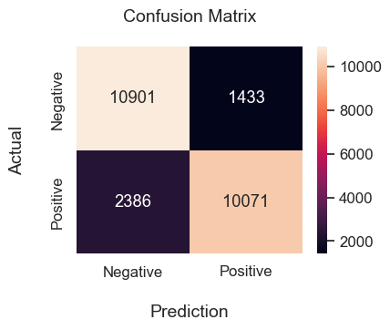

```python
conf_matrix = confusion_matrix(y_test,y_pred)
plot_confusion_matrix(conf_matrix)
```

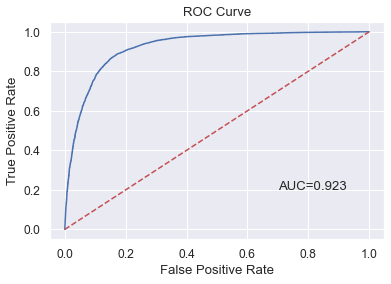

```python
y_pred = nb.predict_proba(X_test)
auc_score = roc_auc_score(y_test, y_pred[:,1])
auc_score_list.append(auc_score)

plot_roc(y_test,y_pred)
```

## Result and Analysis

```python
data = {'Accuracy': accuracy_score_list, 'Precision': precision_score_list, 'Recall':recall_score_list, 'AUC':auc_score_list}
result_df = pd.DataFrame(data)
result_df.index = ['Logistic Regression', 'Decision Tree','Random Forest','KNN', 'Linear SVM','Naive Bayes']
print('Model Results Comparision Table')
result_df
```

```
Model Results Comparision Table
```

|  | Accuracy | Precision | Recall | AUC |
| --- | --- | --- | --- | --- |
| Logistic Regression | 0.864104 | 0.856560 | 0.876294 | 0.938480 |
| Decision Tree | 0.723529 | 0.681715 | 0.843702 | 0.764990 |
| Random Forest | 0.829858 | 0.791192 | 0.898531 | 0.910207 |
| KNN | 0.707353 | 0.690969 | 0.755479 | 0.775399 |
| Linear SVM | 0.866322 | 0.854572 | 0.884483 | 0.938666 |
| Naive Bayes | 0.845952 | 0.875435 | 0.808461 | 0.922836 |

**The table shows that Logistic Regression, Random Forest, Linear SVM, and Naive Bayes seem to be the approriate models for this sentiment analysis. Meanwhile Decision Tree or K-nearest Neighbors seem to underperform. Out of the 4 models that perform well, Linear SVM seems to be the best model with the highest accuracy, and highest AUC. However, Logistic Regression actually does really well too, almost comparable to Linear SVM. In term of computing efficiency, Naive Bayes would be the fastest. But Logistic Regression and Linear SVM are quite fast, while Random Forest is the slowest one because of brute force search.**

## Conclusion

The study helped me learn how to use machine learning algorithms to classify text document based on their polairty, a basic task in sentiment analysis in the field of NFP. I learnt how to encode a document as a feature vector using the bag-of-words model, and also learnt how to weight frequency by using tf-idf.

Through working on the project, I found that apply machine learning algorithm on text data can be computationally expensivve because of large data, or large feature vectors. I had to find ways to work around, find efficient algorithm to convert and calculate the vectors. One solution can be used if I can use mini-batch algorithm to do the job but it is certainly out of scope for the supervised learning.